# The making of FDU interactive record maps

This document details the process, and decisions made, behind the making of interactive record maps for Fungimap target species. The aim of this document is to make transparent the exact methods and data used for producing these maps, and to explain why certain decisions are made for filtering and correcting data.

### Data sources

We gathered records from the Fungimap database, as well as the Atlas of Living Australia (ALA https://www.ala.org.au/), the Global Biodiversity Information Facility (GBIF https://www.gbif.org), iNaturalist https://www.inaturalist.org and the MycoPortal http://mycoportal.org/portal/index.php databases. ALA, GBIF, and iNaturalist are non-fungi-specific databases, so we searched for all records that (1) belong to the kingdom of Fungi, (2) are found in Australia, and (3) are not environmental DNA samples or fossil specimen. In MycoPortal, we searched for all records that are (1) in Australia, (2) are not environmental DNA samples or fossil specimen, and (3) are not from the ALA, since MycoPortal also absorbs data from the ALA. With Fungimap database, we used all records.

In the current version, all data were downloaded as csv files on 14/05/2019 from their respective databases. We have set up a data processing and compilation pipeline below, so that with future downloads, the aggregated database can be updated.

Here, we use a **small fraction** of the original data to demonstrate how we process these data — this means that results displayed here will be different from those in the full analysis.

### Data loading

```r
#set global options for reading csv files
options(fill=TRUE, stringsAsFactors = FALSE, header = TRUE, fileEncoding="UTF-8", na.strings = c(""," ","NA"), row.names = NULL)
#load all data and uppercase all colnames

GBIF <- read.csv("Data/GBIF.csv")
colnames(GBIF) <- toupper(colnames(GBIF))
####important note for GBIF: open downloaded GBIF data in excel and save as CSV manually, because R recognises original GBIF format as tab-delimited, which does not work well with our NA string argument (teating tab as NA)
ALA <- read.csv("Data/ALA.csv")
colnames(ALA) <- toupper(colnames(ALA))
MycoPortal <- read.table("Data/MycoPortal.csv", sep= ",", fill = TRUE, header = TRUE)
colnames(MycoPortal) <- toupper(colnames(MycoPortal))
iNaturalist <- read.csv("Data/iNaturalist.csv")
colnames(iNaturalist) <- toupper(colnames(iNaturalist))
Fungimap <- read.csv("Data/fungimap.csv")
colnames(Fungimap) <- toupper(colnames(Fungimap))
Fungimap.GnR <- read.csv("Data/fungimap-GatesRatkowsky.csv")
colnames(Fungimap.GnR) <- toupper(colnames(Fungimap.GnR))
```

### Data filtering

For each dataset, we filter them based on a number of criteria

```r
##############we will filter through the data one criterion at a time:#######################
#  ONE ----- keeping only records identified to species level
##some datasets contain records at higher taxonomic level, we will remove them. This is not necessary, because such data will be excluded later when matching to Latin binomials of target species. However, as we deal with large dataset, have this preliminary exclusion of unnecessary data can speed up later processing.
#ALA:
table(ALA$TAXON.RANK)
```

```
##
##      class     family      genus    kingdom      order     phylum
##          1         16        244         11          6          3
##    species subspecies    variety
##        705          8          6
```

```r
#as seen here, ALA data contains multiple taxonomic ranks, however, we also know that some species gets mis-coded as genus when older synonyms are used. For this reason, we are not filtering ALA data based on species yet.
#GBIF:
table(GBIF$TAXONRANK)
```

```
##
##      CLASS     FAMILY       FORM      GENUS    KINGDOM      ORDER
##         27         28          2        227         36         31
##     PHYLUM    SPECIES SUBSPECIES    VARIETY
##         17        617          4         11
```

```r
#keep species level and below
GBIF.filtered <- GBIF[GBIF$TAXONRANK %in% c("SPECIES","SUBSPECIES","VARIETY","FORM"),]
#MycoPortal -- we use SPECIFICEPITHET column to sort species
MycoPortal.filtered <- MycoPortal[MycoPortal$SPECIFICEPITHET != "",]
###inaturalist and fungimap are all species level, so we will not be filtering them

# TWO ---- we will remove any records without long/lat information

#for ALA, all records missing coordinates are missing both lat and long, but we will remove any without either long or lat, to be future proof
ALA.filtered <- ALA[!(is.na(ALA$LONGITUDE) | is.na(ALA$LATITUDE)),]

#for GBIF, we first coerce all lat and long into numbers (so all non-numerical long/lat values will be coerced into NAs), then we remove NAs.

GBIF.filtered$DECIMALLATITUDE <- as.numeric(GBIF.filtered$DECIMALLATITUDE)
GBIF.filtered$DECIMALLONGITUDE <- as.numeric(GBIF.filtered$DECIMALLONGITUDE)
GBIF.filtered <- GBIF.filtered[!(is.na(GBIF.filtered$DECIMALLONGITUDE) | is.na(GBIF.filtered$DECIMALLATITUDE)),]

#mycoportal we do the same
MycoPortal.filtered$DECIMALLATITUDE <- as.numeric(MycoPortal.filtered$DECIMALLATITUDE)
MycoPortal.filtered$DECIMALLONGITUDE <- as.numeric(MycoPortal.filtered$DECIMALLONGITUDE)
MycoPortal.filtered <- MycoPortal.filtered[!(is.na(MycoPortal.filtered$DECIMALLONGITUDE) | is.na(MycoPortal.filtered$DECIMALLATITUDE)),]

#iNaturalist does not have NA, but we do this too to be future proof
iNaturalist.filtered <- iNaturalist[!(is.na(iNaturalist$LONGITUDE) | is.na(iNaturalist$LATITUDE)),]
#also we remove non-research grad iNat data
iNaturalist.filtered <- iNaturalist[iNaturalist$QUALITY_GRADE == "research",]


#fungimap, we remove NAs
Fungimap.filtered <- Fungimap[!(is.na(Fungimap$LONGDET) | is.na(Fungimap$LATDEC)),]
#fungimapGNR has no NA either, but we also incude the code to be future-proof
Fungimap.GnR.filtered <- Fungimap.GnR[!(is.na(Fungimap.GnR$LONGDET) | is.na(Fungimap.GnR$LATDEC)),]
```

### Pre-processing before combining data

Before we can merge the datasets, we need to make sure they contain the same columns of the same information, so some pre-processing is needed. Unlike the previous stage, here we are not throwing away data, but modifying/adding content.

```r
#######################pre-process before combine data#################
#define the type of information we want to retain from different datasets
col.selected <- c("SOURCE", "ID", "SPECIES", "STATE", "LOCALITY DESCRIPTION", "POSITIONAL ACCURACY", "DATE", "LONGITUDE", "LATITUDE", "BASIS OF RECORD", "IDENTIFIER ID", "SUBSTRATE", "HABITAT")
#Fungimap datasets do not have a data column yet (date info stored in separate comlumns of DMY), so we add a date column to fungimap
Fungimap.filtered$EVENTDATE <- paste(Fungimap.filtered$YEAR,Fungimap.filtered$MONTH, Fungimap.filtered$DAY, sep = "-")
Fungimap.GnR.filtered$EVENTDATE <- paste(Fungimap.GnR.filtered$YEAR,Fungimap.GnR.filtered$MONTH, Fungimap.GnR.filtered$DAY, sep = "-")
#also replace fungimap species id with species name
funginame.lookup <- read.csv("Data/funginames.csv")
Fungimap.filtered$SPECIES <- funginame.lookup$name[match(Fungimap.filtered$SP_NO,funginame.lookup$id)]
Fungimap.GnR.filtered$SPECIES <- funginame.lookup$name[match(Fungimap.GnR.filtered$SP_NO,funginame.lookup$id)]
#replace PRCODE values in fungimap data with metres
#remember 1= within 50m, 2= within 1km, 3= within 10km, 4= within 25km, 5= greater than 25km, 6= indefinable within Aus.
unique(Fungimap.filtered$PRCODE)
```

```
## [1]  2  1 NA  3  5  4
```

```r
Fungimap.filtered$PRCODE[Fungimap.filtered$PRCODE == "1"] <- 50
Fungimap.filtered$PRCODE[Fungimap.filtered$PRCODE == "2"] <- 1000
Fungimap.filtered$PRCODE[Fungimap.filtered$PRCODE %in% c("2-3","3")] <- 10000
Fungimap.filtered$PRCODE[Fungimap.filtered$PRCODE == "4"] <- 25000
Fungimap.filtered$PRCODE[Fungimap.filtered$PRCODE == "5"] <- 50000 #use this to represent larger than 25km
Fungimap.filtered$PRCODE[Fungimap.filtered$PRCODE %in% c("","6","#N/A")] <- NA
unique(Fungimap.GnR.filtered$PRCODE)
```

```
## [1]  1 NA  2
```

```r
Fungimap.GnR.filtered$PRCODE[Fungimap.GnR.filtered$PRCODE == "1"] <- 50
Fungimap.GnR.filtered$PRCODE[Fungimap.GnR.filtered$PRCODE == "2"] <- 1000
Fungimap.GnR.filtered$PRCODE[Fungimap.GnR.filtered$PRCODE %in% c("2-3","3")] <- 10000
Fungimap.GnR.filtered$PRCODE[Fungimap.GnR.filtered$PRCODE == ""] <- NA
#add a source column to all datasets
ALA.filtered$SOURCE <- rep("ALA",nrow(ALA.filtered))
GBIF.filtered$SOURCE <- rep("GBIF",nrow(GBIF.filtered))
MycoPortal.filtered$SOURCE <- rep("MycoPortal",nrow(MycoPortal.filtered))
iNaturalist.filtered$SOURCE <- rep("iNat",nrow(iNaturalist.filtered))
Fungimap.filtered$SOURCE <- rep("Fungimap",nrow(Fungimap.filtered))
Fungimap.GnR.filtered$SOURCE <- rep("Fungimap",nrow(Fungimap.GnR.filtered))
```

### Combining data

```r
####remember Fungimap and MycoPortal go first because they have substrate and habitat info
AAF.ver1 <- data.frame("SOURCE" = c(Fungimap.filtered$SOURCE,
                                    Fungimap.GnR.filtered$SOURCE,
                                    MycoPortal.filtered$SOURCE,
                                    ALA.filtered$SOURCE,
                                    GBIF.filtered$SOURCE,
                                    iNaturalist.filtered$SOURCE),
                       "ORIGINAL.ID" = c(Fungimap.filtered$ID,
                                Fungimap.GnR.filtered$ID,
                                MycoPortal.filtered$ID,
                                ALA.filtered$RECORD.ID,
                                GBIF.filtered$GBIFID,
                                iNaturalist.filtered$ID),
                       "SPECIES" = c(Fungimap.filtered$SPECIES,
                                     Fungimap.GnR.filtered$SPECIES,
                                     MycoPortal.filtered$SCIENTIFICNAME,
                                     ALA.filtered$SPECIES,
                                     GBIF.filtered$SPECIES,
                                     iNaturalist.filtered$SCIENTIFIC_NAME),
                       "STATE" = c(Fungimap.filtered$STATE,
                                   Fungimap.GnR.filtered$STATE,
                                   MycoPortal.filtered$STATEPROVINCE,
                                   ALA.filtered$STATE...PARSED,
                                   GBIF.filtered$COUNTRYCODE,
                                   rep("AUSTRALIA",
                                       nrow(iNaturalist.filtered))),
                       "LOCALITY DESCRIPTION" = c(Fungimap.filtered$LOCALITY,
                                                  Fungimap.GnR.filtered$LOCALITY,
                                                  MycoPortal.filtered$LOCALITY,
                                                  ALA.filtered$LOCALITY,
                                                  GBIF.filtered$LOCALITY,
                                                  iNaturalist.filtered$PLACE_GUESS),
                       "POSITIONAL ACCURACY" = c(Fungimap.filtered$PRCODE,
                                                 Fungimap.GnR.filtered$PRCODE,
                                                 MycoPortal.filtered$COORDINATEUNCERTAINTYINMETERS,
                                                 ALA.filtered$COORDINATE.UNCERTAINTY.IN.METRES,
                                                 GBIF.filtered$COORDINATEUNCERTAINTYINMETERS,
                                                 iNaturalist.filtered$POSITIONAL_ACCURACY),
                       "DATE" = c(Fungimap.filtered$EVENTDATE,
                                  Fungimap.GnR.filtered$EVENTDATE,
                                  MycoPortal.filtered$EVENTDATE,
                                  ALA.filtered$EVENT.DATE...PARSED,
                                  GBIF.filtered$EVENTDATE,
                                  iNaturalist.filtered$OBSERVED_ON),
                       "LONGITUDE" = c(Fungimap.filtered$LONGDET,
                                       Fungimap.GnR.filtered$LONGDET,
                                       MycoPortal.filtered$DECIMALLONGITUDE,
                                       ALA.filtered$LONGITUDE,
                                       GBIF.filtered$DECIMALLONGITUDE,
                                       iNaturalist.filtered$LONGITUDE),
                           "LATITUDE" = c(Fungimap.filtered$LATDEC,
                                          Fungimap.GnR.filtered$LATDEC,
                                          MycoPortal.filtered$DECIMALLATITUDE,
                                          ALA.filtered$LATITUDE,
                                          GBIF.filtered$DECIMALLATITUDE,
                                          iNaturalist.filtered$LATITUDE),
                       "BASIS OF RECORD" = c(rep("Human observation",
                                                 nrow(Fungimap.filtered)),
                                             rep("Human observation",
                                                 nrow(Fungimap.GnR.filtered)),
                                             MycoPortal.filtered$BASISOFRECORD,
                                             ALA.filtered$BASIS.OF.RECORD,
                                             GBIF.filtered$BASISOFRECORD,
                                             rep("Human observation",
                                                 nrow(iNaturalist.filtered))
                                             ),
                        "IDENTIFIER ID" = c(Fungimap.filtered$RECORDED_BY,
                                            Fungimap.GnR.filtered$RECORDED_BY,
                                            MycoPortal.filtered$RECORDEDBY,
                                            ALA.filtered$COLLECTOR,
                                            GBIF.filtered$RECORDEDBY,
                                            iNaturalist.filtered$USER_ID),
                           "SUBSTRATE" = c(Fungimap.filtered$SUBSTRATE,
                                           Fungimap.GnR.filtered$SUBSTRATE,
                                           MycoPortal.filtered$SUBSTRATE,
                                           rep("NOT REPORTED",
                                               nrow(ALA.filtered)),
                                           rep("NOT REPORTED",
                                               nrow(GBIF.filtered)),
                                           rep("NOT REPORTED",
                                               nrow(iNaturalist.filtered))
                                           ),
                           "HABITAT" = c(Fungimap.filtered$HABITAT,
                                         Fungimap.GnR.filtered$HABITAT,
                                         MycoPortal.filtered$HABITAT,
                                         rep("NOT REPORTED",
                                             nrow(ALA.filtered)),
                                         rep("NOT REPORTED",
                                             nrow(GBIF.filtered)),
                                         rep("NOT REPORTED",
                                             nrow(iNaturalist.filtered))
                                         ),
                       stringsAsFactors = FALSE
)
#add a temporary column for ALA original name (only ALA has this column)
AAF.ver1$ALA.ORIGINAL.SPECIES <- c(rep(NA,length(c(Fungimap.filtered$SOURCE,
                                                 Fungimap.GnR.filtered$SOURCE,
                                                 MycoPortal.filtered$SOURCE))),
                                   ALA.filtered$SCIENTIFIC.NAME...ORIGINAL,
                                   rep(NA,(nrow(GBIF.filtered) + nrow(iNaturalist.filtered))))
####good, remove WIP files
rm(list = ls()[-which(ls() == "AAF.ver1")]) #this line is irrelevant here, but useful for saving memory when working with the real dataset
gc()
```

```
##           used (Mb) gc trigger (Mb) limit (Mb) max used (Mb)
## Ncells  480511 25.7    1057627 56.5         NA   630522 33.7
## Vcells 1028640  7.9    8388608 64.0      16384  2574350 19.7
```

Let’s have a look what the data looks like

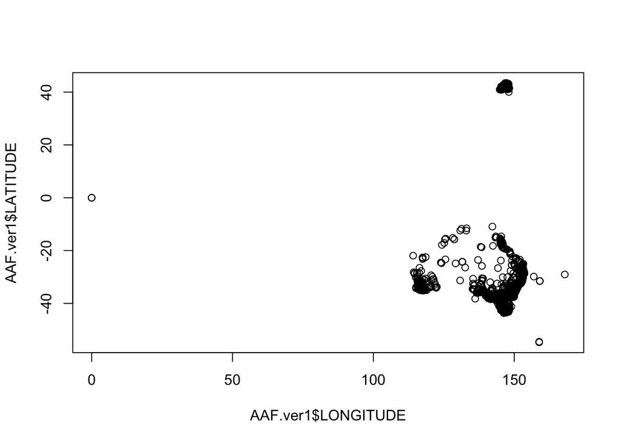

Some obvious problems stand out — there is a clump of records in the northern hemisphere that appears to have flipped latitudes, and there are a number of records outside Australia. We’ll fix them.

```r
#flip lat
AAF.ver1$LATITUDE <- ifelse(AAF.ver1$LATITUDE > 0, -AAF.ver1$LATITUDE,AAF.ver1$LATITUDE)
#chuck out anything with impossible long or lat
AAF.ver1 <- AAF.ver1[AAF.ver1$LONGITUDE < 180 & AAF.ver1$LONGITUDE > -180, ]
AAF.ver1 <- AAF.ver1[AAF.ver1$LATITUDE < 0 & AAF.ver1$LATITUDE > -90, ]

#use a blank AUstralia raster to remove out-of-Australia points
library(raster)
AUS.raster <- raster("Data/ONE GRID TO RULE THEM ALL/AUS_GDA94AA_GRID_MASK_1000.tif")

#convert coordinate to GDA94
geo.coord <- SpatialPoints(coords = AAF.ver1[,c("LONGITUDE","LATITUDE")],proj4string = CRS("+init=epsg:4326"))
albers.coord <- spTransform(geo.coord,crs(AUS.raster))
#decimal meters are pointless, round them to integers
#first change back to df
albers.coord <- as.matrix(as.data.frame(albers.coord))
albers.coord <- trunc(albers.coord,0)
albers.coord <- apply(albers.coord,2,as.integer)
#get back to df
albers.coord <- as.data.frame(albers.coord)
names(albers.coord) <- c("ALBERS X", "ALBERS Y")
#done
AAF.ver1  <- cbind(AAF.ver1,albers.coord)
#use the raster to get rid of out of australia points
AAF.ver1 <-  AAF.ver1[complete.cases(extract(AUS.raster,AAF.ver1[,15:16])),]
```

Check what the data looks like now

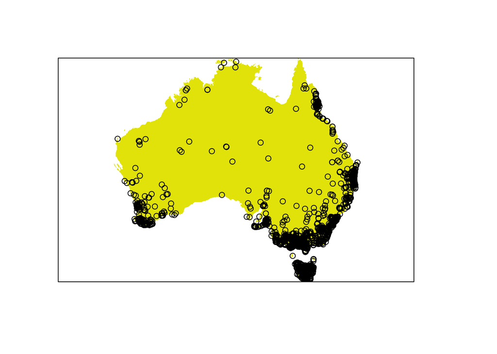

Looking good, at this stage we can save our final product, so that we can load it directly for further uses.

The codes below saves our final dataset as both a csv file and a RData file, they are not executed here, but I used them in my original workflow — this is not a necessity, but you could do the same if you want to replicate exactly my procedures.

```r
save(AAF.ver1, file = "Output/AAFver1.RData")
write.csv(AAF.ver1,file = "Output/AAFver1.csv", row.names = FALSE, fileEncoding="UTF-8")
```

### Filtering Fungimap target species

At this stage, we have collated records from all sources, for all species (and possibly other taxonomic units). This could be useful for exploring other questions (e.g. community composition or species turnover), but for now we select only Fungimap target species for making maps.

Run the folloiwng line to re-load species data into your R environment, if you have saved them and started a new session, like I originally did.

```r
#load species data
load("Output/AAFver1.RData")
```

Execute the following codes for subsetting all data to all Fungimap species.

```r
#load the target species list
targetspecieslist <- read.csv("Data/synonyms.csv", stringsAsFactors = FALSE)
#check the structure of it
head(targetspecieslist)
```

```
##                ALL.NAMES          DATABASE.NAME
## 1  Agaricus xanthodermus  Agaricus xanthodermus
## 2    Agrocybe parasitica   Cyclocybe parasitica
## 3       Aleuria aurantia       Aleuria aurantia
## 4        Aleuria rhenana   Sowerbyella rhenana
## 5    Aleurina ferruginea    Aleurina ferruginea
## 6 Amanita aff. hemibapha Amanita aff. hemibapha
```

```r
#you will see this table has two columns - one denoting the "true" species name (DATABASE.NAME) we are using in our final dataframe, and one denoting all associated synonyms (ALL.NAMES)

#remove any possible duplicate true-synonym pairs - there should not be any but we do this just to be sure
targetspecieslist <- targetspecieslist[!duplicated(targetspecieslist$ALL.NAMES),]


#subset to only target species
AAF.target <- AAF.ver1[AAF.ver1$SPECIES %in% targetspecieslist$ALL.NAMES|AAF.ver1$ALA.ORIGINAL.SPECIES %in% targetspecieslist$ALL.NAMES,]
#okay, remove non-target dataframe - we do not need it anymore
rm(AAF.ver1)

#these lines of codes replaces synonyms with "true" species names. Remember that we kept a 'original name' column for ALA data, so that we can bypass ALA's built-in synonym algorithm, if necessary.
AAF.target$SPECIES <- ifelse(is.na(AAF.target$ALA.ORIGINAL.SPECIES),
    targetspecieslist$DATABASE.NAME[match(AAF.target$SPECIES,targetspecieslist$ALL.NAMES)],
    ifelse(is.na(targetspecieslist$DATABASE.NAME[match(AAF.target$ALA.ORIGINAL.SPECIES,targetspecieslist$ALL.NAMES)]),targetspecieslist$DATABASE.NAME[match(AAF.target$SPECIES,targetspecieslist$ALL.NAMES)],targetspecieslist$DATABASE.NAME[match(AAF.target$ALA.ORIGINAL.SPECIES,targetspecieslist$ALL.NAMES)]))
```

At this point, we can run the following to check how many species have records, and which species are missing. Here we are not doing this because we are using a much smaller example set of records, so a lot more species are missing.

```r
#check how many species in general
length(unique(AAF.target$SPECIES))
#238 - looks right
#remove the column for ALA orignal names - this is no longer needed
AAF.target <- AAF.target[,-14]
#print names of no record species - these are the FDU target species with no records at all presently
unique(targetspecieslist$DATABASE.NAME)[!(unique(targetspecieslist$DATABASE.NAME) %in% unique(AAF.target$SPECIES))]
```

### Flag duplicates

So far, we have kept all duplicate records, so that we have information about which databases contain those duplicates. However, for mapping those records, it is more reasonable to keep merge all duplicates into one copy. Here we do this by adding a column to annotate all possible duplicates for each record, then remove those duplicates from the dataframe.

Run the following line to reproduce all what we did prior to this point, if you are working in a new session.

```r
#we try to flag duplicate datasets
#load species data
source("Scripts/FUNGIMAP target set.R")
```

First, we find all records with the same species name, and same coordinates (we are using Australian Albers GDA94 coordinates here because R processes integer coordinates faster, but long/lat works too). This means situations in which the same species is recorded in the same location at different times will also be treated as duplicates. This does not make sense for some applications (e.g. species accumulation curve over time), but for mapping this is okay.

```r
AAF.target.no.dup <- AAF.target[!duplicated(AAF.target[,c("SPECIES","ALBERS X", "ALBERS Y")]),]
```

Run the following to add a column to annotate duplicates for each unique combination of species and coordinates. This code uses a for loop through the entire dataset, which is slow (and likely not the most efficient way to do this). I may improve this in the future, but for now you can use the same code to annotate duplicates. On my computer, this takes ~9 hours for the full dataset (but it will be a lot faster for this example dataset used here).

```r
#use system.time to time how long the operation takes
system.time(
    for (i in 1:nrow(AAF.target.no.dup)) {
        annotation <- merge(AAF.target, AAF.target.no.dup[i,c("SPECIES","ALBERS X", "ALBERS Y")], by.x = c("SPECIES","ALBERS X", "ALBERS Y"), all.x = FALSE, all.y = TRUE)
        annotation <- paste(apply(annotation[,4:5], 1, paste, collapse=" "), collapse=" ")
        AAF.target.no.dup$DUPLICATION.ANNOTATION[i] <- annotation
    }
)
```

```
##    user  system elapsed
##   2.033   0.021   2.077
```

```r
#check what the data looks like
head(AAF.target.no.dup, n = 5)
```

```
##          SOURCE ORIGINAL.ID                    SPECIES           STATE
## 1999 MycoPortal     5478713 Tremella mesenterica group South Australia
## 2000 MycoPortal     5471715          Drechmeria gunnii        Tasmania
## 2001 MycoPortal     6967583       Marasmiellus affixus        Victoria
## 2004 MycoPortal     5554131   Leucocoprinus birnbaumii      Queensland
## 2005 MycoPortal     5453665       Marasmiellus affixus        Tasmania
##                      LOCALITY.DESCRIPTION POSITIONAL.ACCURACY       DATE
## 1999 Mount Remarkable NP: Alligator Gorge                  50 2002-06-25
## 2000                                                      100 2004-05-14
## 2001             Wombat Forest, , VIC, AU                   5 2018-06-03
## 2004          Deeragun, Dundabella Drive.                1000 2014-02-18
## 2005                                                      100 2005-05-06
##      LONGITUDE  LATITUDE   BASIS.OF.RECORD                  IDENTIFIER.ID
## 1999  138.2411 -32.60139  HumanObservation   Fungimap Recorder Number: 49
## 2000  147.3667 -41.30000  HumanObservation            Ratkowsky, D. David
## 2001  144.2856 -37.47480 Human Observation                  morganchloe84
## 2004  146.6708 -19.25611  HumanObservation Fungimap Recorder Number: 1580
## 2005  146.7000 -42.68333  HumanObservation            Ratkowsky, D. David
##      SUBSTRATE                                             HABITAT
## 1999           Eucalyptus camaldulensis open woodland; steep gorge
## 2000
## 2001
## 2004
## 2005
##      ALA.ORIGINAL.SPECIES ALBERS X ALBERS Y DUPLICATION.ANNOTATION
## 1999                 <NA>   580987 -3568781     MycoPortal 5478713
## 2000                 <NA>  1312273 -4594810     MycoPortal 5471715
## 2001                 <NA>  1090331 -4148972     MycoPortal 6967583
## 2004                 <NA>  1534346 -2149631     MycoPortal 5554131
## 2005                 <NA>  1238406 -4736870     MycoPortal 5453665
```

```r
#we see that there is now an extra column named "DUPLICATION.ANNOTATION", which details the SOURCE and ORIGINAL.ID in which the record is found. For the rows we are looking at here, there are no duplicates, thus all the "DUPLICATION.ANNOTATION" information only points to single records.
```

Use the following to save the de-duplicated copy of the data, here we are not running them.

```r
###save this
save(AAF.target.no.dup,file = "Output/AAFdupannotated.RData")
write.csv(AAF.target.no.dup, file = "Output/AAFdupannotated.csv", row.names = FALSE, fileEncoding="UTF-8")
```

### Map-making

Now we are finally ready to make maps.

```r
#load the package mapview for making maps, and viridis for colour scheme
library(mapview); library(viridis)
```

Again, use the following to load data, if it is not in your environment yet.

```r
#load species data
load("Output/AAFdupannotated.RData")
```

We first turn basis of records into a facet-able factor.

```r
#check what documentation there are
unique(AAF.target.no.dup$BASIS.OF.RECORD)
```

```
## [1] "HumanObservation"   "Human Observation"  "PreservedSpecimen"
## [4] "Observation"        ""                   "Image"
## [7] "HUMAN_OBSERVATION"  "PRESERVED_SPECIMEN" "Human observation"
```

```r
#collapse into human observation, preserved specimen, or else
AAF.target.no.dup$BASIS.OF.RECORD[AAF.target.no.dup$BASIS.OF.RECORD %in% c("PreservedSpecimen","Exsiccati","PRESERVED_SPECIMEN","Preserved Specimen")] <- "Preserved Specimen"
AAF.target.no.dup$BASIS.OF.RECORD[AAF.target.no.dup$BASIS.OF.RECORD %in% c("HumanObservation","HUMAN_OBSERVATION","Observation","Human Observation","Human observation")] <- "Human Observation"
AAF.target.no.dup$BASIS.OF.RECORD[!(AAF.target.no.dup$BASIS.OF.RECORD %in% c("Human Observation","Preserved Specimen"))] <- "Others"
unique(AAF.target.no.dup$BASIS.OF.RECORD)
```

```
## [1] "Human Observation"  "Preserved Specimen" "Others"
```

```r
#good
#turn into a factor
AAF.target.no.dup$BASIS.OF.RECORD <- as.factor(AAF.target.no.dup$BASIS.OF.RECORD)
```

```r
####interactive maps through the mapview package
for (sp in 1:length(unique(AAF.target.no.dup$SPECIES))) {
    sp.sf <- st_as_sf(AAF.target.no.dup[AAF.target.no.dup$SPECIES == unique(AAF.target.no.dup$SPECIES)[sp],], coords = (14:15), crs = crs(AUS.raster))
    mapshot(mapview(sp.sf, layer.name = unique(AAF.target.no.dup$SPECIES)[sp], homebutton = F, zcol = "BASIS.OF.RECORD", colour = viridis(3)), url = paste0(unique(AAF.target.no.dup$SPECIES)[sp],".html"))

}
```